# Storm Data Human Harm and Economic Damage Analysis

## Synopsis

This work analyzes the [National Weather Service’s Storm Data](https://d396qusza40orc.cloudfront.net/repdata%2Fpeer2_doc%2Fpd01016005curr.pdf) to answer the questions:

1. Across the United States, which types of events (as indicated in the EVTYPE variable) are most harmful with respect to population health?
2. Across the United States, which types of events have the greatest economic consequences?

We divide “harm to population health” into “Fatalities” and “Injuries” and conclude that:

1. The most deadly storm type events are “TORNADO”, “EXCESSIVE HEAT”, “FLASH FLOOD”, “LIGHTNING”, and “THUNDERSTORM”, and “FLOOD”, with “TORNADO” and “EXCESSIVE HEAT” being responsible for more than half of the human deaths.
2. The storm type events that caused the most human injuries are “TORNADO”, “THUNDERSTORM”, “EXCESSIVE HEAT”, “FLOOD”, “LIGHTNING”, and “ICE STORM”, with “TORNADO” alone being responsible for about two-thirds of the injuries.
3. The events that caused the most economic damage are “FLOOD”, “HURRICANE”, “TORNADO”, “STORM SURGE”, “FLASH FLOOD”, and “HAIL”.

## Data Processing

In this section we install and load the required packages, download the Storm Data, along with it’s documentation and FAQ, and then, based on the United States Severe Weather Terminology, we rename Event Types that we have identified as to be equal to one another. For example, observations with EVTYPE equal to ‘TSTM WINDS’ are of the same EVTYPE of observations with EVTYPE equal to ‘THUNDERSTORM WINDS’, which in turn, according to the terminology, belong both in the ‘THUNDERSTORM’ category. Similarly, ‘EXCESSIVE HEAT’ and ‘RECORD HEAT’ are both considered ‘EXCESSIVE HEAT’.

```r
InstallAndLoadRequiredPackages <- function() {
  # Load the required packages.
  if (!require('pacman')) {
    install.packages('pacman')
  }
  pacman::p_load(data.table, dtplyr, stringr, tidyverse)
}

InstallAndLoadRequiredPackages()
```

```r
ReadStormData <- function() {
  storm.data.url <- 'https://d396qusza40orc.cloudfront.net/repdata%2Fdata%2FStormData.csv.bz2'

  storm.data.filename <- 'StormData.csv.b2z'

  if (!file.exists(storm.data.filename)) {
    download.file(storm.data.url, storm.data.filename)
    download.file('https://d396qusza40orc.cloudfront.net/repdata%2Fpeer2_doc%2Fpd01016005curr.pdf',
                  'StormData_documentation.pdf',
                  mode = 'wb')
    download.file('https://d396qusza40orc.cloudfront.net/repdata%2Fpeer2_doc%2FNCDC%20Storm%20Events-FAQ%20Page.pdf',
                  'StormData_faq.pdf',
                  mode = 'wb')
  }

  read.csv(storm.data.filename)
}

RenameEqualEvTypes <-function(storm.data) {
  storm.data <- storm.data %>%
    mutate(EVTYPE = toupper(EVTYPE))

  # Consolidates based on: https://en.wikipedia.org/wiki/Severe_weather_terminology_(United_States)
  # Marine events have special treatment
  storm.data[str_detect(storm.data$EVTYPE, 'TSTM|THUNDERSTORM') &
               !str_detect(storm.data$EVTYPE, 'NON|MARINE|SEA|COASTAL'), ]$EVTYPE <- 'THUNDERSTORM'

  storm.data[str_detect(storm.data$EVTYPE, 'TORNADO') &
               !str_detect(storm.data$EVTYPE, 'NON|MARINE|SEA|COASTAL|WATER'), ]$EVTYPE <- 'TORNADO'

  storm.data[str_detect(storm.data$EVTYPE, 'MARINE THUNDER|SEA THUNDER|MARINE TSTM|SEA TSTM'),
             ]$EVTYPE <- 'MARINE THUNDERSTORM'

  storm.data[str_detect(storm.data$EVTYPE, 'WINTER') &
               !str_detect(storm.data$EVTYPE, 'NON|MARINE|SEA|COASTAL|STORM|SNOW'),
             ]$EVTYPE <- 'WINTER WEATHER'

  storm.data[str_detect(storm.data$EVTYPE, 'WINTER STORM') &
               !str_detect(storm.data$EVTYPE, 'NON|MARINE|SEA|COASTAL|SNOW'), ]$EVTYPE <- 'WINTER STORM'

  storm.data[str_detect(storm.data$EVTYPE, 'BLIZZARD') &
               !str_detect(storm.data$EVTYPE, 'NON|MARINE|SEA|COASTAL|HEAVY'), ]$EVTYPE <- 'BLIZZARD'

  storm.data[str_detect(storm.data$EVTYPE, 'HEAVY SNOW') &
               !str_detect(storm.data$EVTYPE, 'NON|MARINE|SEA|COASTAL|STORM|ICE'), ]$EVTYPE <- 'HEAVY SNOW'

  storm.data[str_detect(storm.data$EVTYPE, 'LAKE-EFFECT SNOW') &
               !str_detect(storm.data$EVTYPE, 'NON|MARINE|SEA|COASTAL'), ]$EVTYPE <- 'LAKE-EFFECT SNOW'

  storm.data[str_detect(storm.data$EVTYPE, 'FREEZING RAIN') &
               !str_detect(storm.data$EVTYPE, 'NON|MARINE|SEA|COASTAL'), ]$EVTYPE <- 'FREEZING RAIN'

  storm.data[str_detect(storm.data$EVTYPE, 'ICE STORM') &
               !str_detect(storm.data$EVTYPE, 'NON|MARINE|SEA|COASTAL'), ]$EVTYPE <- 'ICE STORM'

  storm.data[str_detect(storm.data$EVTYPE, 'TROPICAL STORM') &
               !str_detect(storm.data$EVTYPE, 'NON|MARINE|SEA|COASTAL'), ]$EVTYPE <- 'TROPICAL STORM'

  storm.data[str_detect(storm.data$EVTYPE, 'HURRICANE') &
               !str_detect(storm.data$EVTYPE, 'NON|MARINE|SEA|COASTAL'), ]$EVTYPE <- 'HURRICANE'

  storm.data[str_detect(storm.data$EVTYPE, 'FLOOD') &
               !str_detect(storm.data$EVTYPE, 'NON|MARINE|SEA|FLASH|COASTAL|LAKE|RIVER|URBAN|SMALL|STREET'),
             ]$EVTYPE <- 'FLOOD'

  storm.data[str_detect(storm.data$EVTYPE, 'FLASH FLOOD') &
               !str_detect(storm.data$EVTYPE, 'NON|MARINE|SEA|COASTAL|LAKE|RIVER|URBAN|SMALL|STREET'),
             ]$EVTYPE <- 'FLASH FLOOD'

  storm.data[str_detect(storm.data$EVTYPE, 'COASTAL FLOOD|COAST FLOOD|MARINE FLOOD|SEA FLOOD') &
               !str_detect(storm.data$EVTYPE, 'NON|LAKE|RIVER|URBAN|SMALL|STREET'),
             ]$EVTYPE <- 'COASTAL FLOOD'

  storm.data[str_detect(storm.data$EVTYPE, 'LAKESHORE FLOOD|LAKE FLOOD') &
               !str_detect(storm.data$EVTYPE, 'NON|MARINE|SEA|COASTAL|RIVER|URBAN|SMALL|STREET'),
             ]$EVTYPE <- 'LAKESHORE FLOOD'

  storm.data[str_detect(storm.data$EVTYPE, 'RIVER FLOOD') &
               !str_detect(storm.data$EVTYPE, 'NON|MARINE|SEA|COASTAL|LAKE|URBAN|SMALL|STREET'),
             ]$EVTYPE <- 'RIVER FLOOD'

  storm.data[str_detect(storm.data$EVTYPE, 'URBAN FLOOD|STREET FLOOD|SMALL STREAM FLOOD|SMALL FLOOD') &
               !str_detect(storm.data$EVTYPE, 'NON|MARINE|SEA|COASTAL'),
             ]$EVTYPE <- 'URBAN AND SMALL STREAM FLOOD'

  storm.data[str_detect(storm.data$EVTYPE, 'HEAT') &
               !str_detect(storm.data$EVTYPE, 'NON|MARINE|SEA|COASTAL'), ]$EVTYPE <- 'EXCESSIVE HEAT'

  storm.data[str_detect(storm.data$EVTYPE, 'CHILL') &
               !str_detect(storm.data$EVTYPE, 'NON|MARINE|SEA|COASTAL|COLD'), ]$EVTYPE <- 'WIND CHILL'

  storm.data[str_detect(storm.data$EVTYPE, 'COLD') &
               !str_detect(storm.data$EVTYPE, 'NON|MARINE|SEA|COASTAL|CHILL'), ]$EVTYPE <- 'EXTREME COLD'

  storm.data[str_detect(storm.data$EVTYPE, 'FREEZE') &
               !str_detect(storm.data$EVTYPE, 'NON|MARINE|SEA|COASTAL'), ]$EVTYPE <- 'FREEZE'

  storm.data[str_detect(storm.data$EVTYPE, 'MARINE STORM|SEA STORM|COASTAL STORM') &
               !str_detect(storm.data$EVTYPE, 'NON'), ]$EVTYPE <- 'COASTAL STORM'

  storm.data[str_detect(storm.data$EVTYPE, 'HIGH SURF') &
               !str_detect(storm.data$EVTYPE, 'NON'), ]$EVTYPE <- 'HIGH SURF'

  storm.data[str_detect(storm.data$EVTYPE, 'HIGH WIND') &
               !str_detect(storm.data$EVTYPE, 'NON|MARINE|SEA|COASTAL'), ]$EVTYPE <- 'HIGH WIND'

  storm.data[str_detect(storm.data$EVTYPE, 'HEAVY RAIN') &
               !str_detect(storm.data$EVTYPE, 'NON|MARINE|SEA|COASTAL'), ]$EVTYPE <- 'HEAVY RAIN'

  storm.data
}

if (!exists('storm.data')) {
  storm.data <- ReadStormData()
  storm.data <- RenameEqualEvTypes(storm.data)
}
```

## Results

### Which types of events (as indicated in the EVTYPE variable) are most harmful with respect to population health?

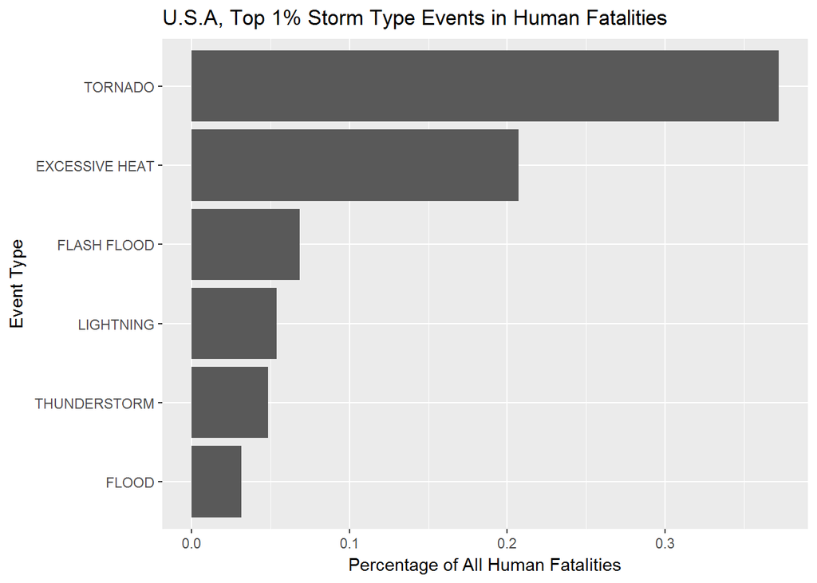

```r
fatalities.per.event.type <- storm.data %>%
  group_by(EVTYPE) %>%
  summarise(FATALITIES = sum(FATALITIES)) %>%
  mutate(PERCENTAGE_OF_FATALITIES = FATALITIES / sum(FATALITIES))

most.fatalities.event.types <- fatalities.per.event.type %>%
  filter(FATALITIES > quantile(FATALITIES, probs = 1 - 1/100)) %>%
  arrange(desc(FATALITIES))

injuries.per.event.type <- storm.data %>%
  group_by(EVTYPE) %>%
  summarise(INJURIES = sum(INJURIES)) %>%
  mutate(PERCENTAGE_OF_INJURIES = INJURIES / sum(INJURIES))

most.injuries.event.types <- injuries.per.event.type %>%
  filter(INJURIES > quantile(INJURIES, probs = 1 - 1 / 100)) %>%
  arrange(desc(PERCENTAGE_OF_INJURIES))

most.fatalities.event.types %>%
  ggplot(aes(reorder(EVTYPE, PERCENTAGE_OF_FATALITIES), PERCENTAGE_OF_FATALITIES)) +
  geom_col() +
  coord_flip() +
  ggtitle('U.S.A, Top 1% Storm Type Events in Human Fatalities') +
  ylab('Percentage of All Human Fatalities') +
  xlab('Event Type')
```

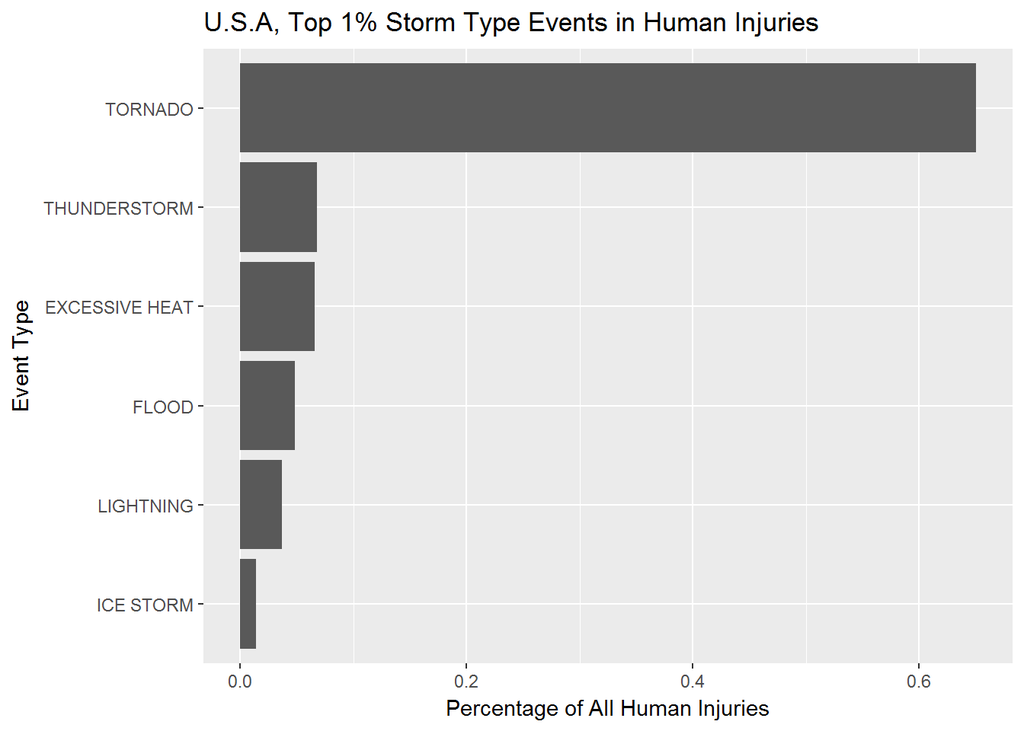

```r
most.injuries.event.types %>%
  ggplot(aes(reorder(EVTYPE,PERCENTAGE_OF_INJURIES), PERCENTAGE_OF_INJURIES)) +
  geom_col() +
  coord_flip() +
  ggtitle('U.S.A, Top 1% Storm Type Events in Human Injuries') +
  ylab('Percentage of All Human Injuries') +
  xlab('Event Type')
```

### Across the United States, which types of events have the greatest economic consequences?

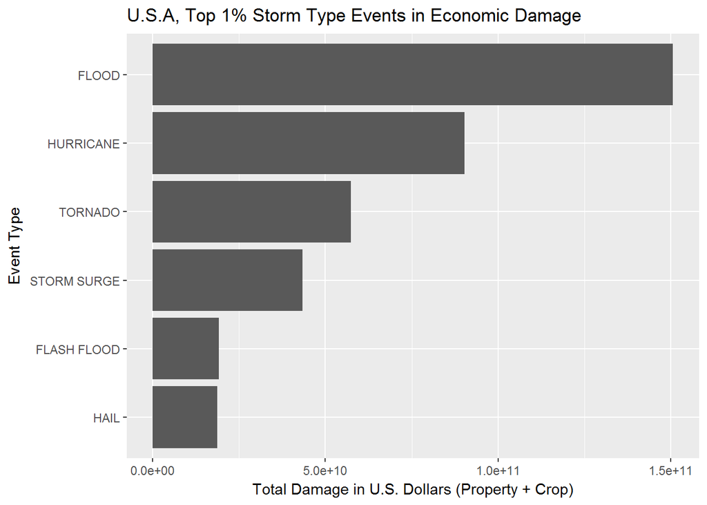

```r
ExpToMultiplier <- function(e) {
  e <- tolower(e)
  if (e == '?' | e == '+' | e == '-') {
    return(0)
  }
  if (e == 'h') {
    return(10 ^ 2)
  }
  if (e == 'k') {
    return(10 ^ 3)
  }
  if (e == 'm') {
    return(10 ^ 6)
  }
  if (e == 'b') {
    return(10 ^ 9)
  }
  10 ^ as.numeric(e)
}

damage.by.event.type <- storm.data %>%
  mutate(PROPDMG_IN_DOLLARS = PROPDMG * sapply(PROPDMGEXP, ExpToMultiplier),
         CROPDMG_IN_DOLLARS = CROPDMG * sapply(CROPDMGEXP, ExpToMultiplier)) %>%
  group_by(EVTYPE) %>%
  summarise(TOTAL_DAMAGE_IN_DOLLARS = sum(PROPDMG_IN_DOLLARS, na.rm = TRUE) + sum(CROPDMG_IN_DOLLARS, na.rm = TRUE))

events.greatest.economic.consequences <- damage.by.event.type %>%
  filter(TOTAL_DAMAGE_IN_DOLLARS > quantile(TOTAL_DAMAGE_IN_DOLLARS, probs = 1 - 1/100)) %>%
  arrange(desc(TOTAL_DAMAGE_IN_DOLLARS))

events.greatest.economic.consequences %>%
  ggplot(aes(reorder(EVTYPE, TOTAL_DAMAGE_IN_DOLLARS), TOTAL_DAMAGE_IN_DOLLARS)) +
  geom_col() +
  coord_flip() +
  ggtitle('U.S.A, Top 1% Storm Type Events in Economic Damage') +
  ylab('Total Damage in U.S. Dollars (Property + Crop)') +
  xlab('Event Type')
```